# Introduction to regression

Regression

Brian Caffo, Jeff Leek and Roger Peng

## A famous motivating example

### (Perhaps surprisingly, this example is still relevant)

http://www.nature.com/ejhg/journal/v17/n8/full/ejhg20095a.html

[Predicting height: the Victorian approach beats modern genomics](http://www.wired.com/wiredscience/2009/03/predicting-height-the-victorian-approach-beats-modern-genomics/)

## Finding the middle via least squares

- Consider only the children’s heights.
- How could one describe the “middle”?
- One definition, let $Y_i$ be the height of child $i$ for $i = 1, \ldots, n = 928$, then define the middle as the value of $\mu$ that minimizes
  $$\sum_{i=1}^n (Y_i - \mu)^2$$
- This is physical center of mass of the histrogram.
- You might have guessed that the answer $\mu = \bar X$.

## The least squares estimate is the empirical mean

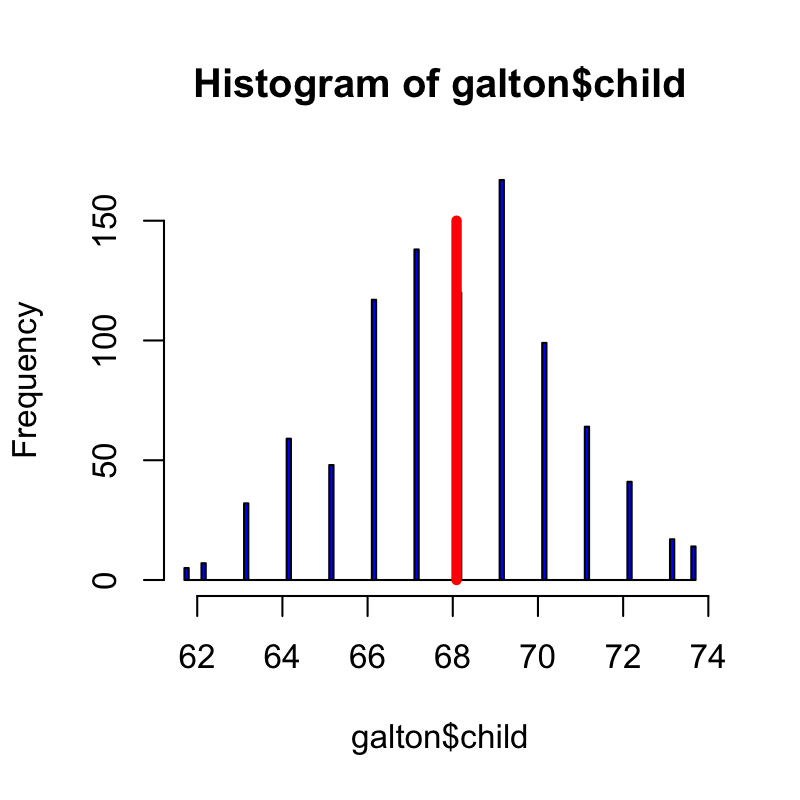

```r
  hist(galton$child,col="blue",breaks=100)
  meanChild <- mean(galton$child)
  lines(rep(meanChild,100),seq(0,150,length=100),col="red",lwd=5)
```

## Comparing childrens’ heights and their parents’ heights

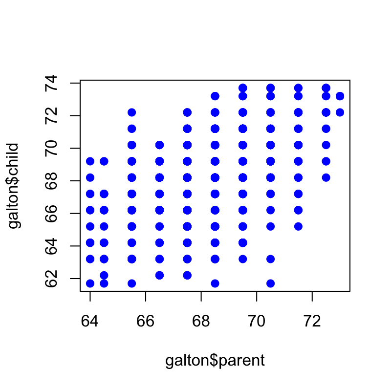

```r
plot(galton$parent,galton$child,pch=19,col="blue")
```

## Regression through the origin

- Suppose that $X_i$ are the parents’ heights.
- Consider picking the slope $\beta$ that minimizes
  $$\sum_{i=1}^n (Y_i - X_i \beta)^2$$
- This is exactly using the origin as a pivot point picking the line that minimizes the sum of the squared vertical distances of the points to the line
- Use R studio’s manipulate function to experiment
- Subtract the means so that the origin is the mean of the parent and children’s heights

## The solution

### In the next few lectures we’ll talk about why this is the solution

```r
lm(I(child - mean(child))~ I(parent - mean(parent)) - 1, data = galton)
```

```
Call:
lm(formula = I(child - mean(child)) ~ I(parent - mean(parent)) -
    1, data = galton)

Coefficients:
I(parent - mean(parent))
                  0.6463
```

## Visualizing the best fit line

### Size of points are frequencies at that X, Y combination

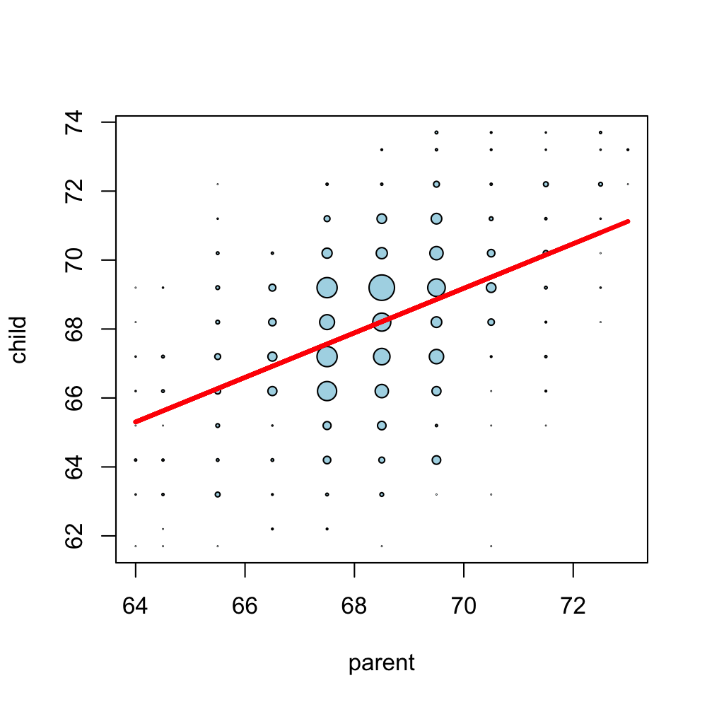